# UK: Household size model

Numerous variables, including age, length of marriage, literacy, preferred number of children, stage of life, etc., affect family size. Having a large family has a variety of drawbacks, including: less money, fewer space, less alone time, someone is constantly fighting, you will get stared at, etc. The size of homes in the UK is the main topic of this research. Less than three people will be considered a small household, and three people or more will be considered a large household. Every model that will be employed will be able to identify factors that affect household size, and the model with the best accuracy will be optimal for forecasting household size in the UK.

```python
#importing the packages
#for data manipulation
import pandas as pd
import numpy as np
#for visualization
import matplotlib.pyplot as plt
import seaborn as sns
sns.set_theme(color_codes=True)
%matplotlib inline
# For metrics and helpful functions
from sklearn.model_selection import GridSearchCV, train_test_split
from sklearn.metrics import accuracy_score, precision_score, recall_score,\
f1_score, confusion_matrix, ConfusionMatrixDisplay, classification_report
from sklearn.metrics import roc_auc_score, roc_curve
```

# Loading the data into dataframe

```python
#loading the data into a dataframe
data=pd.read_csv('Household.csv', encoding='ISO-8859-1')
```

```python
#displaying the dataframe
data
```

|  | sex | age | region | mastat | hushop | hhsize | lstage | nkids | parent | chzerotothree | ... | qual | jbstat | jbrgsc | hoh | jbstathoh | fihhyrtwo | us | mghave | intmg | dfihhyr |
| --- | --- | --- | --- | --- | --- | --- | --- | --- | --- | --- | --- | --- | --- | --- | --- | --- | --- | --- | --- | --- | --- |
| 0 | female | 29.0 | North West | never married | yes | 3 | single | 0 | no | no | ... | gcse/o-level/cse | unemployed | C2 | yes | unemployed | don't know | no | no | not applicable | don't know |
| 1 | female | 43.0 | North West | marrried or couple | no | 4 | family | 2 | yes | no | ... | a-level or equivalent (=nvq3) | in paid employ | B | yes | in paid employ | £75,000-£99,999 | yes | yes | fixed | £700-£799 |
| 2 | female | 53.0 | Yorks&Humber | marrried or couple | no | 2 | post family | 0 | no | no | ... | no formal qualifications | in paid employ | C2 | yes | in paid employ | £25,000-£29,999 | yes | yes | fixed | £300-£399 |
| 3 | female | 36.0 | South West | marrried or couple | no | 4 | family | 2 | yes | yes | ... | vocational qualifications (=nvq1+2) | in paid employ | C2 | yes | in paid employ | £40,000-£49,999 | yes | yes | base rate tracker | £700-£799 |
| 4 | male | 63.0 | Wales | marrried or couple | yes | 2 | post family | 0 | no | no | ... | bachelor degree or equivalent (=nvq4) | retired | B | yes | retired | NaN | yes | no | not applicable | don't know |
| ... | ... | ... | ... | ... | ... | ... | ... | ... | ... | ... | ... | ... | ... | ... | ... | ... | ... | ... | ... | ... | ... |
| 1980 | female | 73.0 | Wales | marrried or couple | yes | 3 | post family | 0 | no | no | ... | no formal qualifications | retired | C2 | yes | retired | £9,500-£11,499 | yes | no | not applicable | £700-£799 |
| 1981 | female | 22.0 | W Midlands | never married | yes | 4 | single | 0 | no | no | ... | a-level or equivalent (=nvq3) | in paid employ | B | no | in paid employ | don't know | yes | yes | not applicable | £300-£399 |
| 1982 | female | 49.0 | Scotland | marrried or couple | no | 5+ | post family | 0 | no | no | ... | other | in paid employ | C1 | yes | in paid employ | NaN | yes | yes | fixed | £1,200-£1,399 |
| 1983 | female | 53.0 | South East | marrried or couple | no | 3 | post family | 0 | no | no | ... | bachelor degree or equivalent (=nvq4) | in paid employ | B | yes | in paid employ | £50,000-£74,999 | yes | yes | fixed | 600-£699 |
| 1984 | male | 34.0 | E Midlands | never married | yes | 5+ | family | 4 | yes | no | ... | no formal qualifications | long-term sick/disab | E | yes | long-term sick/disab | £11,500-£13,499 | no | no | not applicable | <£200 |

1985 rows × 23 columns

# Basic Checks on the data

```python
#displaying the number of rows and columns of the dataframe
data.shape
```

```
(1985, 23)
```

The dataset has 1985 rows and 23 columns.

```python
#displaying the columns of the dataframe
data.columns
```

```
Index(['sex', 'age', 'region', 'mastat', 'hushop', 'hhsize', 'lstage', 'nkids',
       'parent', 'chzerotothree', 'chfourtofive', 'chsixtonine',
       'chtentofifteen', 'qual', 'jbstat', 'jbrgsc', 'hoh', 'jbstathoh',
       'fihhyrtwo', 'us', 'mghave', 'intmg', 'dfihhyr'],
      dtype='object')
```

# Displaying datatypes in our dataframe

```python
#displaying the datatypes
data.dtypes
```

```
sex                object
age               float64
region             object
mastat             object
hushop             object
hhsize             object
lstage             object
nkids              object
parent             object
chzerotothree      object
chfourtofive       object
chsixtonine        object
chtentofifteen     object
qual               object
jbstat             object
jbrgsc             object
hoh                object
jbstathoh          object
fihhyrtwo          object
us                 object
mghave             object
intmg              object
dfihhyr            object
dtype: object
```

The dataset has one datatype which is a float and others that are object type. These object datatypes are categorical variables.

```python
#displaying the basic information of the dataframe
data.info()
```

```
<class 'pandas.core.frame.DataFrame'>
RangeIndex: 1985 entries, 0 to 1984
Data columns (total 23 columns):
 #   Column          Non-Null Count  Dtype
---  ------          --------------  -----
 0   sex             1985 non-null   object
 1   age             1976 non-null   float64
 2   region          1985 non-null   object
 3   mastat          1982 non-null   object
 4   hushop          1985 non-null   object
 5   hhsize          1981 non-null   object
 6   lstage          1983 non-null   object
 7   nkids           1982 non-null   object
 8   parent          1985 non-null   object
 9   chzerotothree   1983 non-null   object
 10  chfourtofive    1983 non-null   object
 11  chsixtonine     1983 non-null   object
 12  chtentofifteen  1983 non-null   object
 13  qual            1985 non-null   object
 14  jbstat          1985 non-null   object
 15  jbrgsc          1985 non-null   object
 16  hoh             1985 non-null   object
 17  jbstathoh       1985 non-null   object
 18  fihhyrtwo       1645 non-null   object
 19  us              1825 non-null   object
 20  mghave          1973 non-null   object
 21  intmg           1945 non-null   object
 22  dfihhyr         1777 non-null   object
dtypes: float64(1), object(22)
memory usage: 356.8+ KB
```

# Explanatory Data Analysis: EDA

# Insights into the dataset

# Univariate:

```
(array([ 0,  1,  2,  3,  4,  5,  6,  7,  8,  9, 10]),
 [Text(0, 0, 'North West'),
```

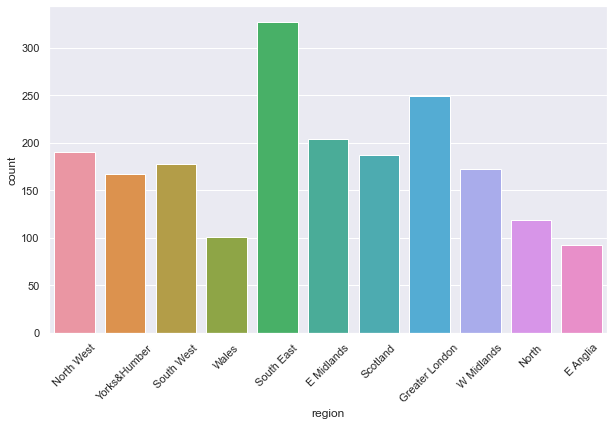

```python
#plotting the figure for regions
plt.figure(figsize=(10,6))
sns.countplot(x="region",data=data)
plt.xticks(rotation=45)
```

From the diagram above, South East is the region with the highest number of people who took part in this study, followed by the Greater London. East Angilia has the least number of people who took part in this study

```
(array([0, 1, 2]),
 [Text(0, 0, 'never married'),
```

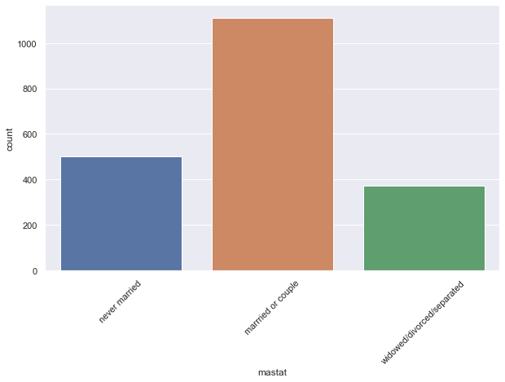

```python
#plotting the figure for marital status of various people
plt.figure(figsize=(10,6))
sns.countplot(x="mastat",data=data)
plt.xticks(rotation=45)
```

From the illustration above, many people who took part in this study are married or couple followed by never married and those who were either widowed, divorved or separated

```
(array([0, 1]), [Text(0, 0, 'yes'), Text(1, 0, 'no')])
```

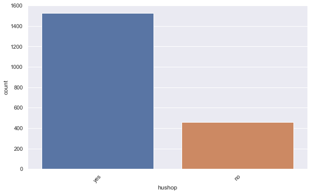

```python
#plotting the figure for hushop
plt.figure(figsize=(10,6))
sns.countplot(x="hushop",data=data)
plt.xticks(rotation=45)
```

On the variable hushop, many people said yes and fewer said no.

```
(array([0, 1, 2, 3]),
 [Text(0, 0, 'single'),
```

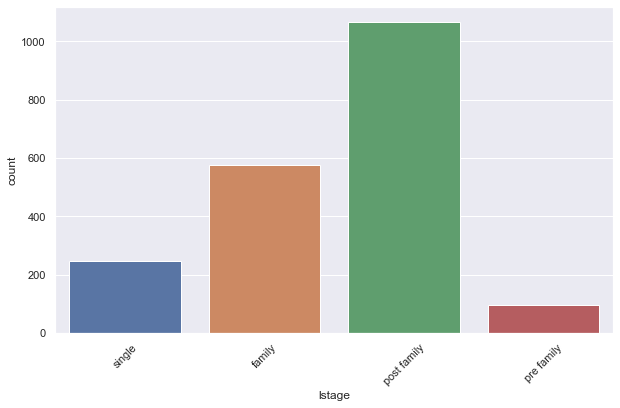

```python
#plotting the fogure for the lifestage of people
plt.figure(figsize=(10,6))
sns.countplot(x="lstage",data=data)
plt.xticks(rotation=45)
```

Many people in this study are post family, followed by the family. The least is pre family as shown by the diagram above

```
(array([0, 1]), [Text(0, 0, 'no'), Text(1, 0, 'yes')])
```

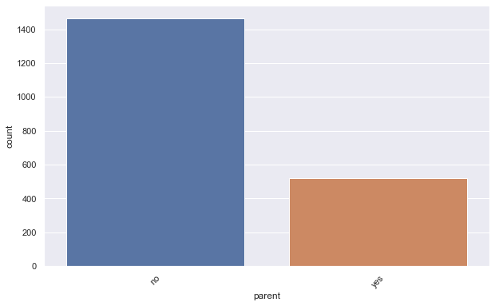

```python
#displaying whether someone is a parent or not
plt.figure(figsize=(10,6))
sns.countplot(x="parent",data=data)
plt.xticks(rotation=45)
```

From the illustration above, there are fewer people who are parents as compared to those that are not parents

```
(array([0, 1]), [Text(0, 0, 'no'), Text(1, 0, 'yes')])
```

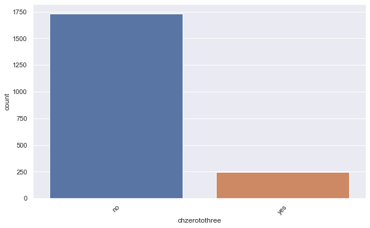

```python
#displaying the channels zero to three listened to by certain individuals
plt.figure(figsize=(10,6))
sns.countplot(x="chzerotothree",data=data)
plt.xticks(rotation=45)
```

Many people in the UK do not listen to channel zero to three. Very few people listen to these channels as shown on our illustration above.

```
(array([0, 1]), [Text(0, 0, 'no'), Text(1, 0, 'yes')])
```

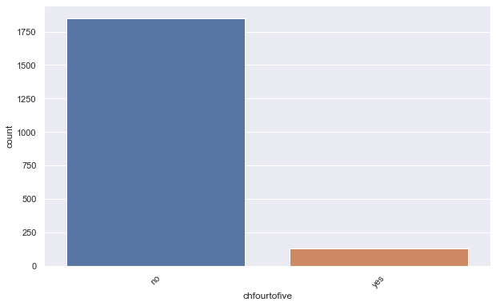

```python
#displaying the channels four to five listened to by certain individuals
plt.figure(figsize=(10,6))
sns.countplot(x="chfourtofive",data=data)
plt.xticks(rotation=45)
```

On the channels four to five, fewer people listen to them as compared to those who do not listen to them.

```
(array([0, 1]), [Text(0, 0, 'no'), Text(1, 0, 'yes')])
```

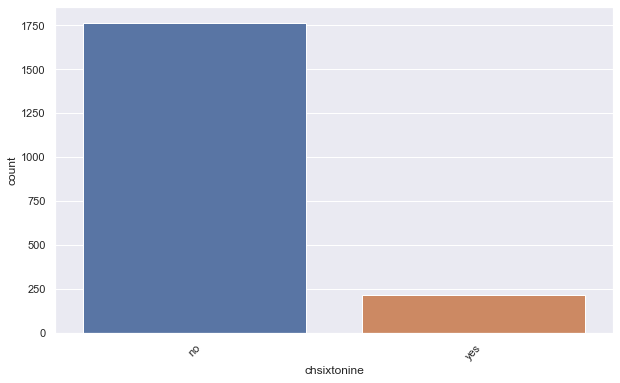

```python
#displaying the channels six to nine that are listened to by certain individuals
plt.figure(figsize=(10,6))
sns.countplot(x="chsixtonine",data=data)
plt.xticks(rotation=45)
```

For the channels six to nine, again fewer people listen to them as compared to those that do not listen to them.

```
(array([0, 1]), [Text(0, 0, 'no'), Text(1, 0, 'yes')])
```

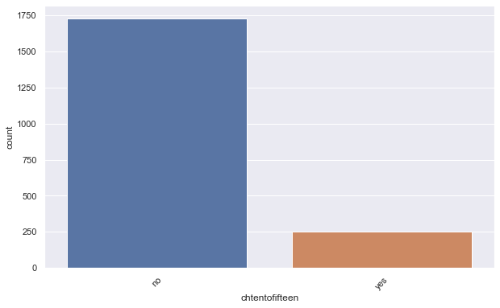

```python
#displaying the channels ten to fifteen that are listened to by certain individuals
plt.figure(figsize=(10,6))
sns.countplot(x="chtentofifteen",data=data)
plt.xticks(rotation=45)
```

Even on the channels ten to fifteen, many people do not listen to them as compared to those those fewer who listen to them. These illustrations are showing almost the same thing that in the UK fewer people listen to radio channels as compared to those do not listen to them.

```
(array([0, 1, 2, 3, 4, 5, 6, 7]),
 [Text(0, 0, 'gcse/o-level/cse'),
```

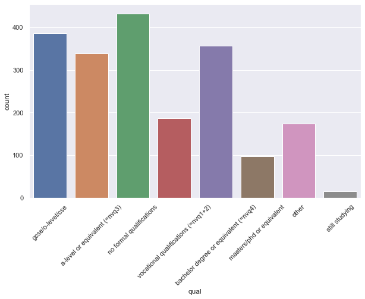

```python
#displaying certain qualification that are possessed by certain individuals
plt.figure(figsize=(10,6))
sns.countplot(x="qual",data=data)
plt.xticks(rotation=45)
```

```
(array([0, 1, 2, 3, 4, 5, 6]),
 [Text(0, 0, 'unemployed'),
```

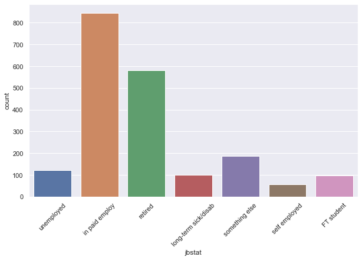

```python
#displaying job status by certain individuals
plt.figure(figsize=(10,6))
sns.countplot(x="jbstat",data=data)
plt.xticks(rotation=45)
```

Most people in the study group in the UK are in in paid employment, followed by the retired. There is a significant number of people doing something else. Again there are some people who are not employed in the UK. On the other hand there are some people who are on the long term sick leave or disabled. For the self-employed group in the UK, they are the least of people of this group.

```
(array([0, 1, 2, 3, 4, 5]),
 [Text(0, 0, 'C2'),
```

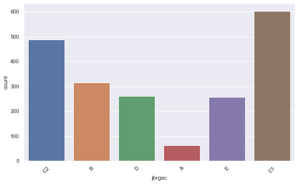

```python
#displaying the job Registrar General's Social Class of certain people
plt.figure(figsize=(10,6))
sns.countplot(x="jbrgsc",data=data)
plt.xticks(rotation=45)
```

For the jbrgsc, there is a number of people in the c1 followed by c2, then B and so on. The last one with the least number is A.

```
(array([0, 1]), [Text(0, 0, 'yes'), Text(1, 0, 'no')])
```

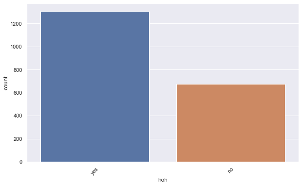

```python
#displaying the head of household (hoh) of certain people whether there are hod or not
plt.figure(figsize=(10,6))
sns.countplot(x="hoh",data=data)
plt.xticks(rotation=45)
```

For hoh, which is the head of household, many people are head of households as compared to those who are not.

```
(array([0, 1, 2, 3, 4, 5, 6]),
 [Text(0, 0, 'unemployed'),
```

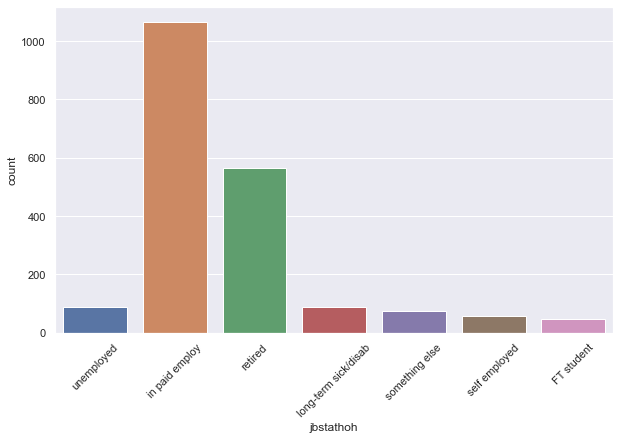

```python
#displaying jobstatus head of household
plt.figure(figsize=(10,6))
sns.countplot(x="jbstathoh",data=data)
plt.xticks(rotation=45)
```

```
(array([ 0,  1,  2,  3,  4,  5,  6,  7,  8,  9, 10, 11, 12, 13, 14, 15, 16]),
 [Text(0, 0, "don't know"),
```

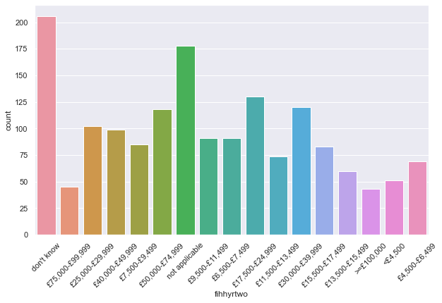

```python
#displaying fihhyrtwo of certain individuals
plt.figure(figsize=(10,6))
sns.countplot(x="fihhyrtwo",data=data)
plt.xticks(rotation=45)
```

```
(array([0, 1, 2]),
 [Text(0, 0, 'no'), Text(1, 0, 'yes'), Text(2, 0, "don't know")])
```

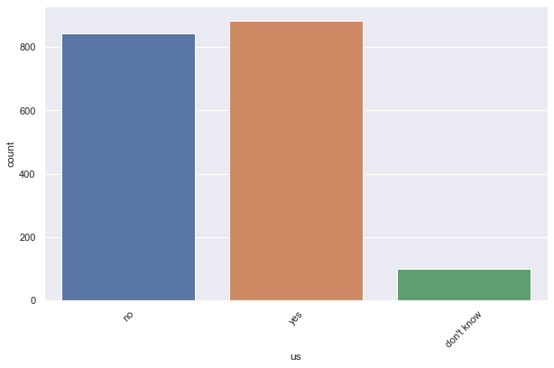

```python
#displayin US of certain individuals
plt.figure(figsize=(10,6))
sns.countplot(x="us",data=data)
plt.xticks(rotation=45)
```

For the US variable many people many people said YES, followed by NO and then do not know.

```
(array([0, 1]), [Text(0, 0, 'no'), Text(1, 0, 'yes')])
```

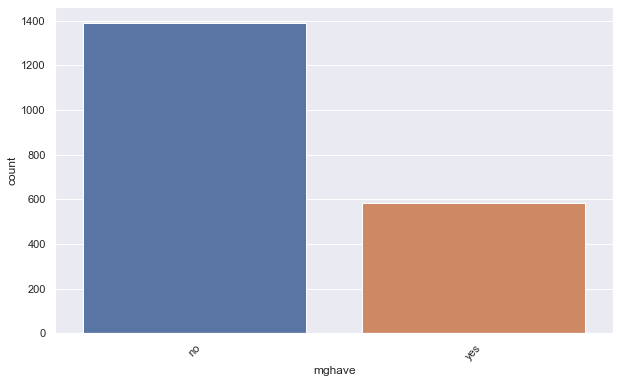

```python
#displaying the mghave in certain people
plt.figure(figsize=(10,6))
sns.countplot(x="mghave",data=data)
plt.xticks(rotation=45)
```

```
(array([0, 1, 2, 3, 4, 5, 6, 7, 8]),
 [Text(0, 0, 'not applicable'),
```

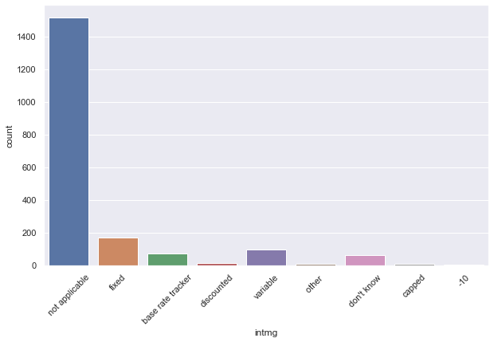

```python
#displaying the intmg of certain individuals
plt.figure(figsize=(10,6))
sns.countplot(x="intmg",data=data)
plt.xticks(rotation=45)
```

On the intmg has the not applicable has the largest number followed by fixed and variable. The least is -10

```
(array([ 0,  1,  2,  3,  4,  5,  6,  7,  8,  9, 10, 11, 12, 13, 14, 15, 16,
        17, 18]),
 [Text(0, 0, "don't know"),
```

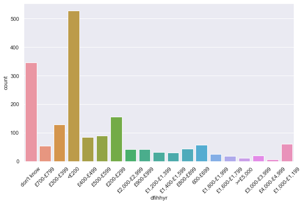

```python
#displaying dfihhyr of certain individuals
plt.figure(figsize=(10,6))
sns.countplot(x="dfihhyr",data=data)
plt.xticks(rotation=45)
```

For the dfihhyr <£200 has the largest value followed by dont know and the least is between £4000-£4999.

```
(array([0, 1, 2, 3, 4, 5]),
 [Text(0, 0, '0'),
```

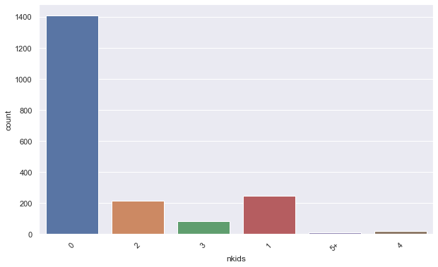

```python
#displaying the number of kids certain individuals have
plt.figure(figsize=(10,6))
sns.countplot(x="nkids",data=data)
plt.xticks(rotation=45)
```

For the nkids many people in this group dont have children followed by those who have one. Those who have two and more are bot that much. Very few people have five and more children. Generally, in the UK, the people do not have a lot of children.

```
(array([0, 1, 2, 3]),
 [Text(0, 0, 'single'),
```

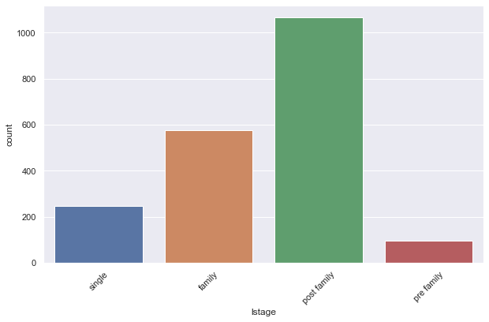

```python
#displaying a certain stage an individual is in
plt.figure(figsize=(10,6))
sns.countplot(x="lstage",data=data)
plt.xticks(rotation=45)
```

In the lstage many people are in the post family stage followed by those in the family stage. Single people in the lstage are may again and the least is that category of those in the pre family. From our illustration, many people in the UK is a older generation which is a post family category.

# Bivariate

```
(array([0, 1, 2, 3, 4]),
 [Text(0, 0, '3'),
```

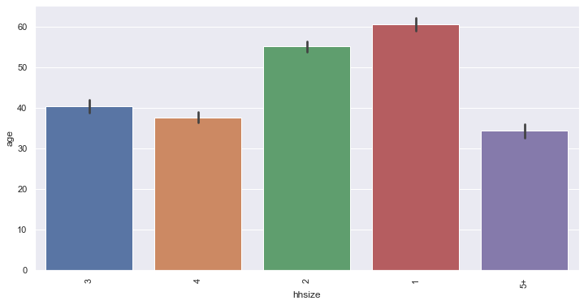

```python
#displaying the number of individuals' age against household size
plt.figure(figsize=(12,6))
sns.barplot(x="hhsize",y="age",data=data)
plt.xticks(rotation=90)
```

From the illustration above, around years of age have he household size is three and around thirty-eight years of age, the household size is on average of four, at around fiftyfive years of age the household size is two. and at sixty years its around 1. So at fifty five and sixty its post family stage as illustrated before. At around thirty five years many people will be having a household size of five and more, meaning that this is the age were parents and children are living together in the UK and many kids are bone during that period.

# Displaying frequency of every column in the dataframe

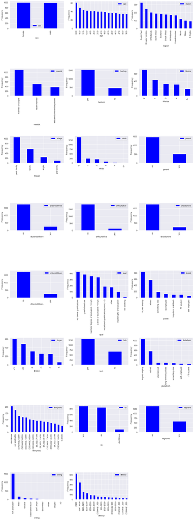

```python
#displaying the frequency of every column in our dataset
fig = plt.figure(figsize=(15,40))
for i in range(len(data.columns)):
 plt.subplot(8, 3, i+1)
 data[data.columns[i]].value_counts().head(15).plot(kind='bar', color="blue")
 plt.xlabel(data.columns[i])
 plt.ylabel("Frequency")
 plt.legend()
 plt.tight_layout()
plt.show()
```

# Checking for missing values in the dataframe

```python
#finding the missing values in our dataset
data.isnull().sum()
```

```
sex                 0
age                 9
region              0
mastat              3
hushop              0
hhsize              4
lstage              2
nkids               3
parent              0
chzerotothree       2
chfourtofive        2
chsixtonine         2
chtentofifteen      2
qual                0
jbstat              0
jbrgsc              0
hoh                 0
jbstathoh           0
fihhyrtwo         340
us                160
mghave             12
intmg              40
dfihhyr           208
dtype: int64
```

The variables which have a corresponding which is not zero have missing values. Age which is a float has missing values and the other objects which are categorical in nature are has missing values.For the float variable which is age, median is going to be used to fill the missing variable. For the missing variables in the categorical form, simple imputer is going to be used.

# Filling in the missing values of the numerical values with the median

```python
#filling in the missing values in our age variable with the median
data['age'].fillna(data['age'].median(), inplace=True)
```

# Filling in the missing categorical variables using Simple imputer

```python
#filling in the missing values in the categorical columns using the simpleimputer
from sklearn.impute import SimpleImputer
impute_mode = SimpleImputer(strategy = 'most_frequent')
impute_mode.fit(data[['mastat', 'mghave','hhsize','lstage','nkids','chzerotothree','chfourtofive','chsixtonine','chsixtonine','chtentofifteen','fihhyrtwo','us','intmg','dfihhyr']])

data[['hhsize','lstage','mastat', 'mghave','nkids','chzerotothree','chfourtofive','chsixtonine','chsixtonine','chtentofifteen','fihhyrtwo','us','intmg','dfihhyr']] = impute_mode.transform(data[['hhsize','lstage','mastat', 'mghave','nkids','chzerotothree','chfourtofive','chsixtonine','chsixtonine','chtentofifteen','fihhyrtwo','us','intmg','dfihhyr']])
```

# Rechecking if there is still missing numerical and categorical variables

```python
#rechecking if there are still missing values in our dataset
data.isnull().sum()
```

```
sex               0
age               0
region            0
mastat            0
hushop            0
hhsize            0
lstage            0
nkids             0
parent            0
chzerotothree     0
chfourtofive      0
chsixtonine       0
chtentofifteen    0
qual              0
jbstat            0
jbrgsc            0
hoh               0
jbstathoh         0
fihhyrtwo         0
us                0
mghave            0
intmg             0
dfihhyr           0
dtype: int64
```

After rechecking for the missing values, no missing values where found.

# Checking for duplicated values

```python
#checking for duplicate values
data.duplicated().sum()
```

```
0
```

No duplicated values are found in our datasets

# Checking for outliers using the age variable

```python
#finding the 75th percentile
percentile75=data['age'].quantile(0.75)
```

```python
#finding the 25th percentile
percentile25=data['age'].quantile(0.25)
```

```python
#finding the interquantile range
iqr=percentile75-percentile25
```

```python
#finding the upper_limit
upper_limit=percentile75+1.5*iqr
```

```python
#finding the lower_limit
lower_limit=percentile25-1.5*iqr
```

```python
#printing the upper_limit and the lower_limit
print("Upper limit:", upper_limit)
print("Lower limit:", lower_limit)
```

```
Upper limit: 110.5
Lower limit: -13.5
```

```python
#printing the outliers
outliers=data[(data['age']>upper_limit)|(data['age']<lower_limit)]
```

```python
#displaying the outliers
print("data in 'age':", len(outliers))
```

```
data in 'age': 0
```

# Checking for outliers using a boxplot

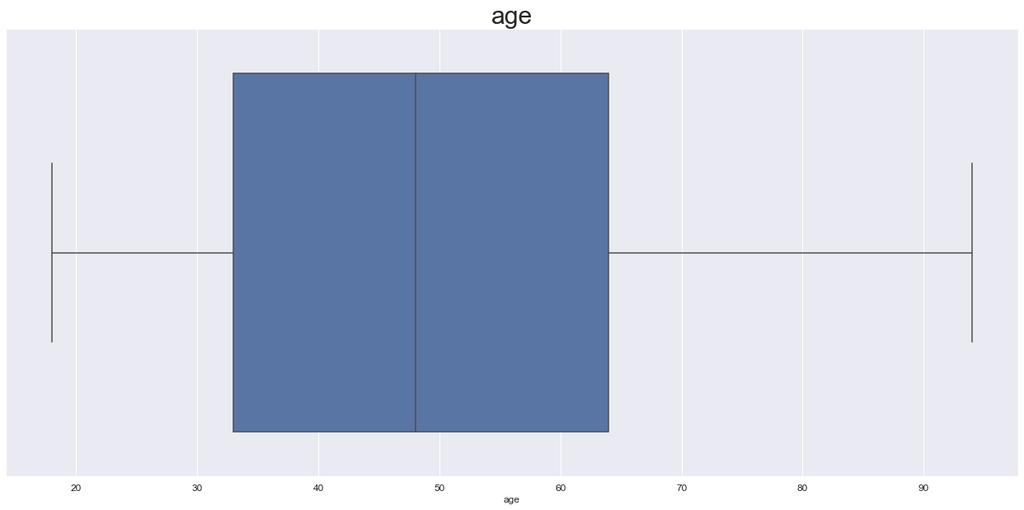

```python
#Checking for outliers using a boxplot
plt.figure(figsize=(22,10))
plt.title('age', fontsize=30)
plt.xticks(fontsize=12)
plt.yticks(fontsize=12)
sns.boxplot(x=data['age']);
```

From the boxplots above, we can see that the age variable has no outliers, which supports the code above that produced an outlier of zero.

# Get the names of all the columns with data type 'object' (categorical columns)

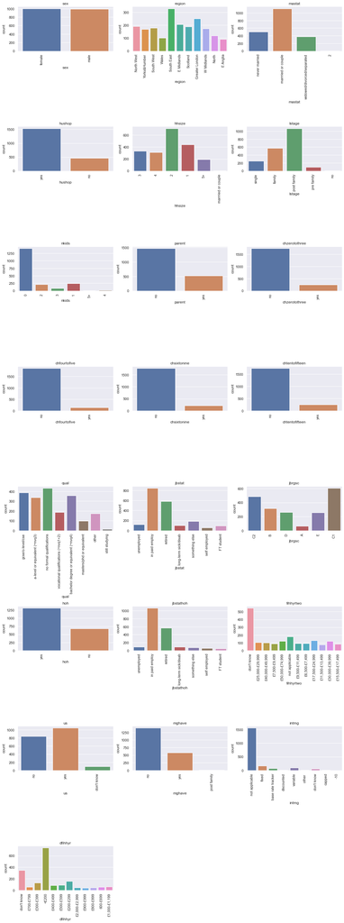

```python
#Get the names of all the columns with data type 'object' (categorical columns)
cat_vars=data.select_dtypes(include='object').columns.tolist()
#Create figure with subplots
num_cols=len(cat_vars)
num_rows=(num_cols+2)//3
fig, axs=plt.subplots(nrows=num_rows, ncols=3, figsize=(15, 5*num_rows))
axs=axs.flatten()
#Create counterplot for the top 5 values of each categorical variable
for i, var in enumerate(cat_vars):
    top_values=data[var].value_counts().nlargest(12).index
    filtered_data=data[data[var].isin(top_values)]
    sns.countplot(x=var, data=filtered_data, ax=axs[i])
    axs[i].set_title(var)
    axs[i].tick_params(axis='x', rotation=90)
#Remove any extra subplots if needed
if num_cols<len(axs):
    for i in range(num_cols, len(axs)):
        fig.delaxes(axs[i])
#Adjust spacing between subplots
fig.tight_layout()
#Show plot
plt.show()
```

# list of the first nine categorical variables to plot

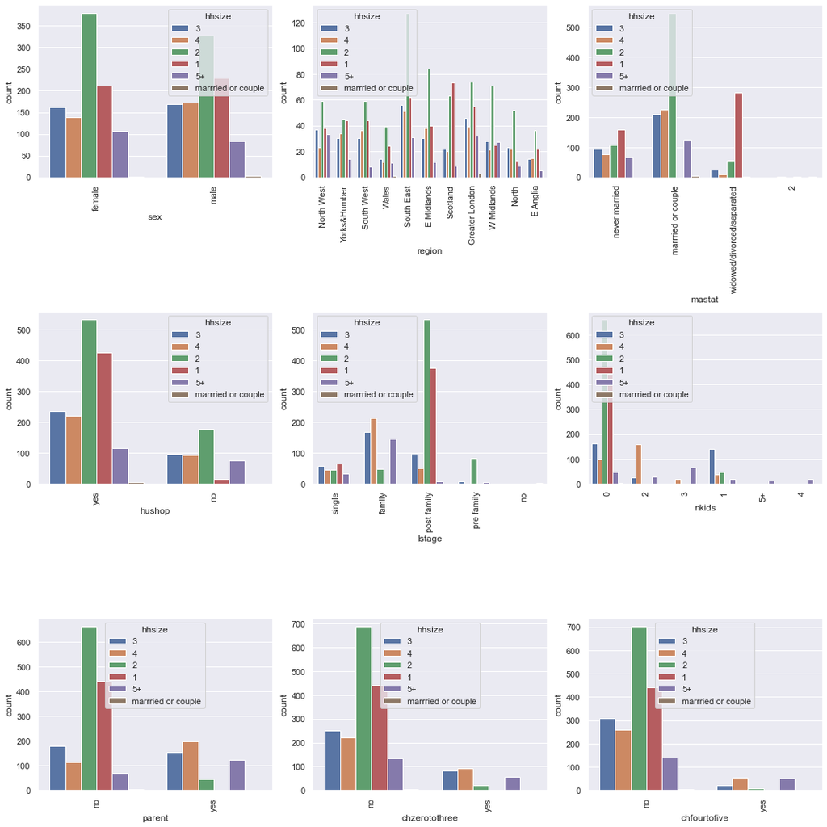

```python
#list of categorical variables to plot
cat_vars=['sex','region','mastat','hushop','lstage','nkids','parent','chzerotothree','chfourtofive']
#create figure with subplots
fig, axs=plt.subplots(nrows=3, ncols=3, figsize=(15,15))
axs=axs.flatten()
#create a barplot for each categorical variable
for i, var in enumerate(cat_vars):
    sns.countplot(x=var, hue='hhsize', data=data, ax=axs[i])
    axs[i].set_xticklabels(axs[i].get_xticklabels(), rotation=90)
#adjust spacing between subplots
fig.tight_layout()
#show plot
plt.show()
```

# list of the second nine categorical variables to plot

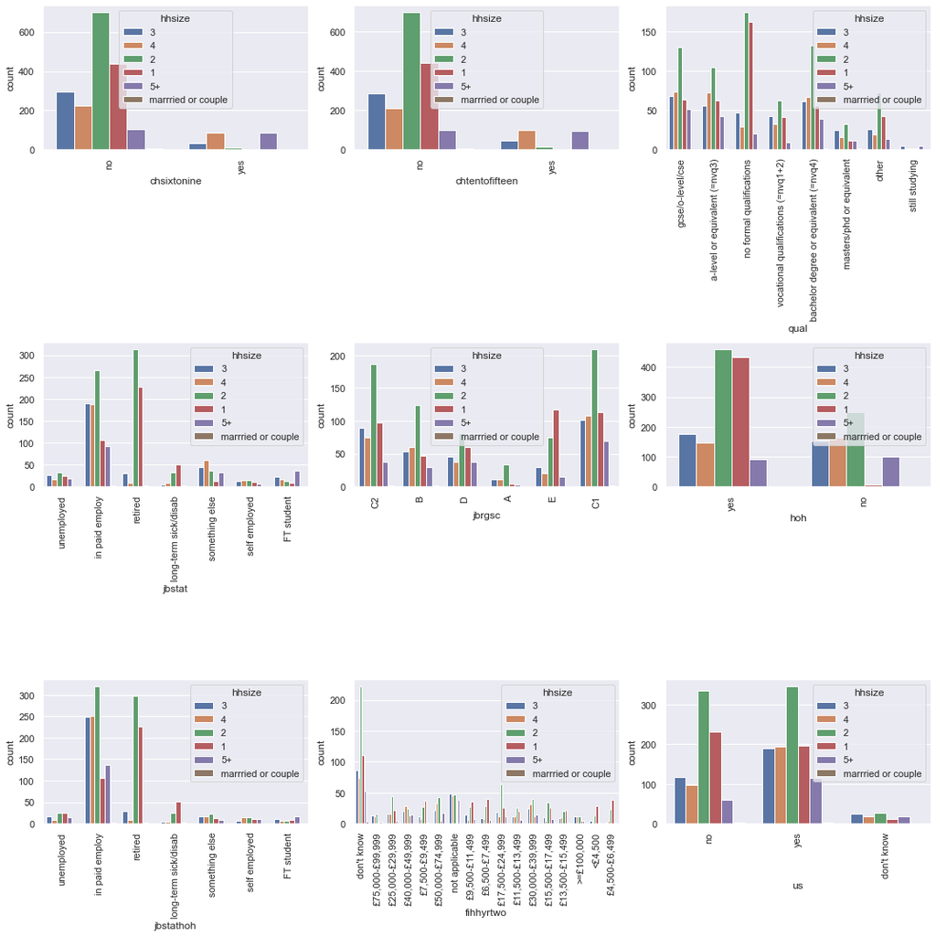

```python
#list of categorical variables to plot
cat_vars=['chsixtonine','chtentofifteen','qual','jbstat','jbrgsc','hoh','jbstathoh','fihhyrtwo','us']
#create figure with subplots
fig, axs=plt.subplots(nrows=3, ncols=3, figsize=(15,15))
axs=axs.flatten()
#create a barplot for each categorical variable
for i, var in enumerate(cat_vars):
    sns.countplot(x=var, hue='hhsize', data=data, ax=axs[i])
    axs[i].set_xticklabels(axs[i].get_xticklabels(), rotation=90)
#adjust spacing between subplots
fig.tight_layout()
#show plot
plt.show()
```

# list of the last three categorical variables to plot

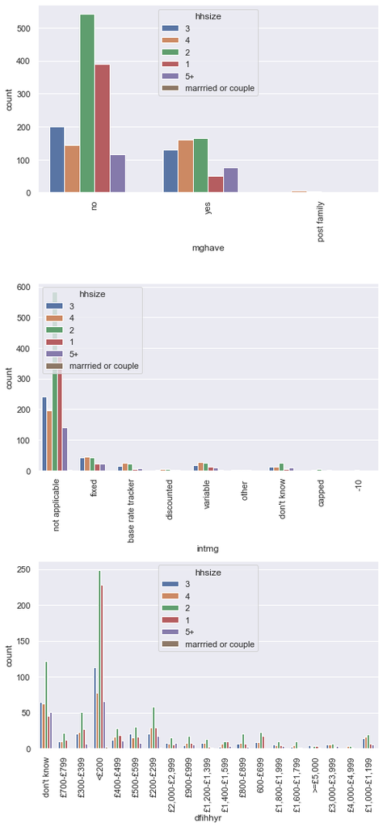

```python
#list of categorical variables to plot
cat_vars=['mghave','intmg','dfihhyr']
#create figure with subplots
fig, axs=plt.subplots(nrows=3, ncols=1, figsize=(7,15))
axs=axs.flatten()
#create a barplot for each categorical variable
for i, var in enumerate(cat_vars):
    sns.countplot(x=var, hue='hhsize', data=data, ax=axs[i])
    axs[i].set_xticklabels(axs[i].get_xticklabels(), rotation=90)
#adjust spacing between subplots
fig.tight_layout()
#show plot
plt.show()
```

# Greating a barplot for the first nine categorical variable

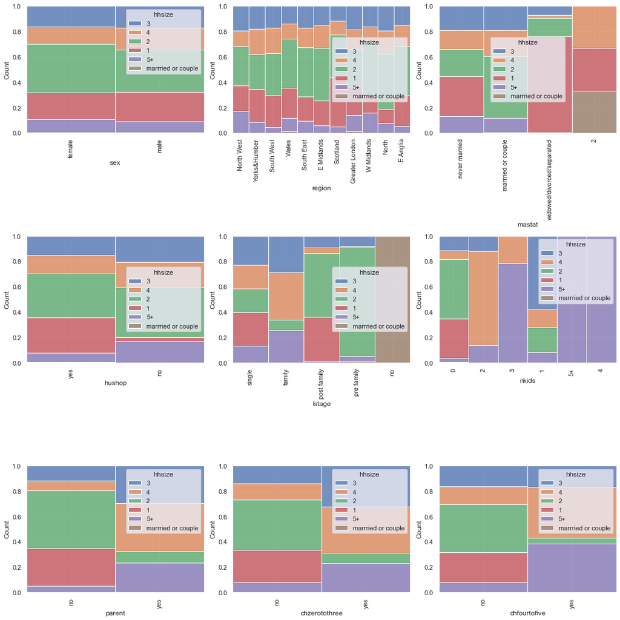

```python
import warnings
warnings.filterwarnings("ignore")
#get list of categorical variables
cat_vars=['sex','region','mastat','hushop','lstage','nkids','parent','chzerotothree','chfourtofive']
#create figure with subplots
fig, axs=plt.subplots(nrows=3, ncols=3, figsize=(15,15))
axs=axs.flatten()
#create a barplot for each categorical variable
for i, var in enumerate(cat_vars):
    sns.histplot(x=var, hue='hhsize', data=data, ax=axs[i], multiple="fill", kde=False)
    axs[i].set_xticklabels(data[var].unique(), rotation=90)
    axs[i].set_xlabel(var)
#adjust spacing between subplots
fig.tight_layout()
#show plot
plt.show()
```

# Creating a barplot for the second nine categorical variable

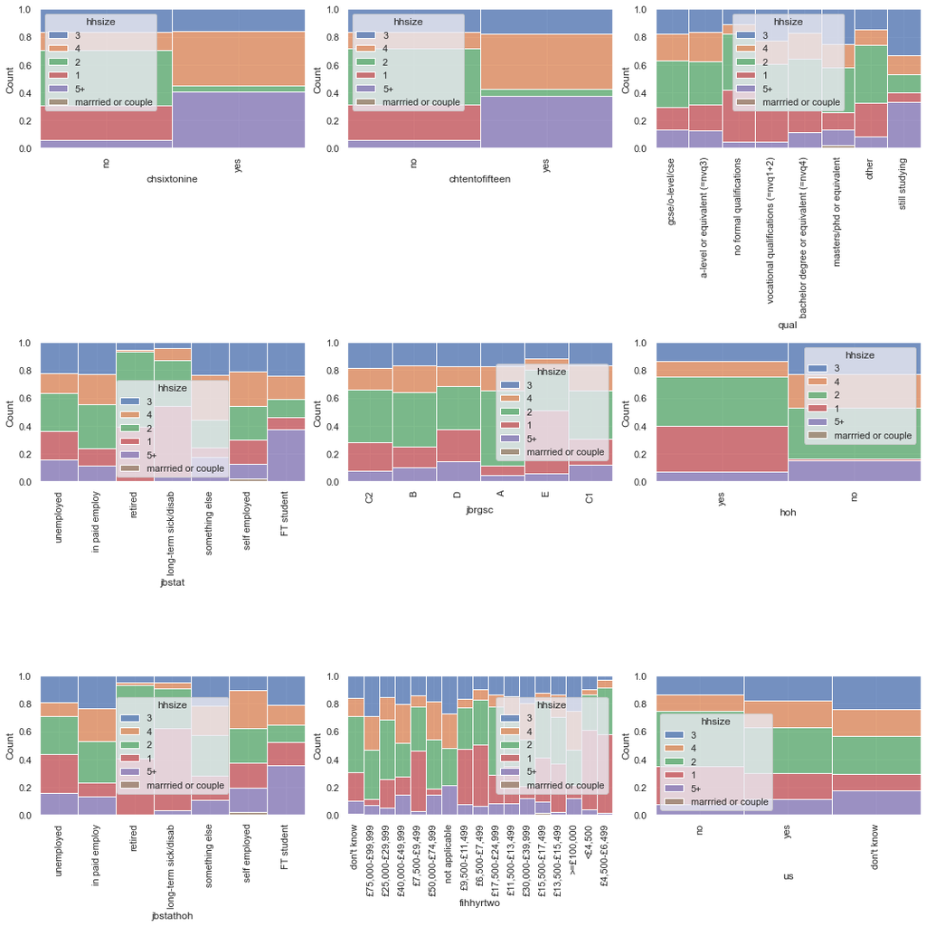

```python
import warnings
warnings.filterwarnings("ignore")
#get list of categorical variables
cat_vars=['chsixtonine','chtentofifteen','qual','jbstat','jbrgsc','hoh','jbstathoh','fihhyrtwo','us']
#create figure with subplots
fig, axs=plt.subplots(nrows=3, ncols=3, figsize=(15,15))
axs=axs.flatten()
#create a barplot for each categorical variable
for i, var in enumerate(cat_vars):
    sns.histplot(x=var, hue='hhsize', data=data, ax=axs[i], multiple="fill", kde=False)
    axs[i].set_xticklabels(data[var].unique(), rotation=90)
    axs[i].set_xlabel(var)
#adjust spacing between subplots
fig.tight_layout()
#show plot
plt.show()
```

# Creating a barplot for each of the last three categorical variables

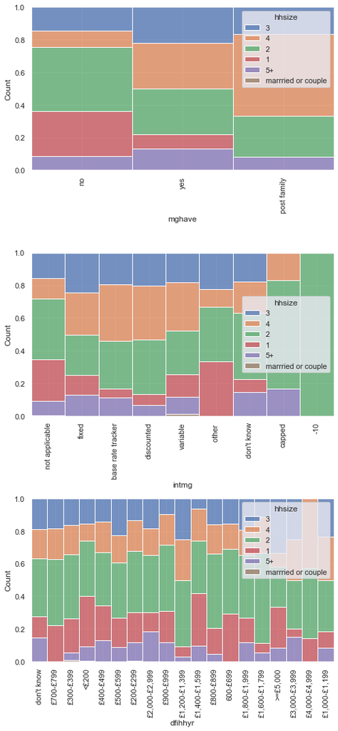

```python
import warnings
warnings.filterwarnings("ignore")
#get list of categorical variables
cat_vars=['mghave','intmg','dfihhyr']
#create figure with subplots
fig, axs=plt.subplots(nrows=3, ncols=1, figsize=(7,15))
axs=axs.flatten()
#create a barplot for each categorical variable
for i, var in enumerate(cat_vars):
    sns.histplot(x=var, hue='hhsize', data=data, ax=axs[i], multiple="fill", kde=False)
    axs[i].set_xticklabels(data[var].unique(), rotation=90)
    axs[i].set_xlabel(var)
#adjust spacing between subplots
fig.tight_layout()
#show plot
plt.show()
```

```python
#displaying the contents of all the categorical variables
for col in data.select_dtypes(include=['object']).columns:
    print(f"{col}:{data[col].unique}")
```

[output not shown]

[output cut: 249 more lines]

# Transformation of the categorical variables into numeriacal variables using LabelEncoder

```python
#transforming the categorical variables to numerical values using label encoder
from sklearn.preprocessing import LabelEncoder
le=LabelEncoder()
```

```python
#transforming the categorical variables to numerical variables
data.sex=le.fit_transform(data.sex)
data.region=le.fit_transform(data.region)
data.mastat=le.fit_transform(data.mastat)
data.hushop=le.fit_transform(data.hushop)
data.hhsize=le.fit_transform(data.hhsize)
data.lstage=le.fit_transform(data.lstage)
data.parent=le.fit_transform(data.parent)
data.nkids=le.fit_transform(data.nkids)
data.chzerotothree=le.fit_transform(data.chzerotothree)
data.chfourtofive=le.fit_transform(data.chfourtofive)
data.chsixtonine=le.fit_transform(data.chsixtonine)
data.chtentofifteen=le.fit_transform(data.chtentofifteen)
data.qual=le.fit_transform(data.qual)
data.jbrgsc=le.fit_transform(data.jbrgsc)
data.hoh=le.fit_transform(data.hoh)
data.jbstathoh=le.fit_transform(data.jbstathoh)
data.fihhyrtwo=le.fit_transform(data.fihhyrtwo)
data.us=le.fit_transform(data.us)
data.mghave=le.fit_transform(data.mghave)
data.intmg=le.fit_transform(data.intmg)
data.dfihhyr=le.fit_transform(data.dfihhyr)
data.jbstat=le.fit_transform(data.jbstat)
```

```python
#checking in the data if there is are still categorical values
data
```

|  | sex | age | region | mastat | hushop | hhsize | lstage | nkids | parent | chzerotothree | ... | qual | jbstat | jbrgsc | hoh | jbstathoh | fihhyrtwo | us | mghave | intmg | dfihhyr |
| --- | --- | --- | --- | --- | --- | --- | --- | --- | --- | --- | --- | --- | --- | --- | --- | --- | --- | --- | --- | --- | --- |
| 0 | 0 | 29.0 | 4 | 2 | 1 | 2 | 4 | 0 | 0 | 0 | ... | 2 | 6 | 3 | 1 | 6 | 2 | 1 | 0 | 6 | 3 |
| 1 | 0 | 43.0 | 4 | 1 | 0 | 3 | 0 | 2 | 1 | 0 | ... | 0 | 1 | 1 | 1 | 1 | 15 | 2 | 2 | 5 | 16 |
| 2 | 0 | 53.0 | 10 | 1 | 0 | 1 | 2 | 0 | 0 | 0 | ... | 4 | 1 | 3 | 1 | 1 | 8 | 2 | 2 | 5 | 12 |
| 3 | 0 | 36.0 | 7 | 1 | 0 | 3 | 0 | 2 | 1 | 1 | ... | 7 | 1 | 3 | 1 | 1 | 11 | 2 | 2 | 1 | 16 |
| 4 | 1 | 63.0 | 9 | 1 | 1 | 1 | 2 | 0 | 0 | 0 | ... | 1 | 3 | 1 | 1 | 3 | 2 | 2 | 0 | 6 | 3 |
| ... | ... | ... | ... | ... | ... | ... | ... | ... | ... | ... | ... | ... | ... | ... | ... | ... | ... | ... | ... | ... | ... |
| 1980 | 0 | 73.0 | 9 | 1 | 1 | 2 | 2 | 0 | 0 | 0 | ... | 4 | 3 | 3 | 1 | 3 | 16 | 2 | 0 | 6 | 16 |
| 1981 | 0 | 22.0 | 8 | 2 | 1 | 3 | 4 | 0 | 0 | 0 | ... | 0 | 1 | 1 | 0 | 1 | 2 | 2 | 2 | 6 | 12 |
| 1982 | 0 | 49.0 | 5 | 1 | 0 | 4 | 2 | 0 | 0 | 0 | ... | 5 | 1 | 2 | 1 | 1 | 2 | 2 | 2 | 5 | 5 |
| 1983 | 0 | 53.0 | 6 | 1 | 0 | 2 | 2 | 0 | 0 | 0 | ... | 1 | 1 | 1 | 1 | 1 | 12 | 2 | 2 | 5 | 0 |
| 1984 | 1 | 34.0 | 1 | 2 | 1 | 4 | 0 | 4 | 1 | 0 | ... | 4 | 2 | 5 | 1 | 2 | 4 | 1 | 0 | 6 | 1 |

1985 rows × 23 columns